# stat37797_simulation

### Reproduce Figure 1 and Figure 6(left) of Zhong et al(2020)

### Figure 1

In a stochastic block model (SBM), assume there are $n$ vertices where $n$ is even. The vertex set $\{1,2,...,n\}$ is divided into two groups $J\in\{1,2,...,n\}$ and $J^c$, where $|J|=n/2$. Let $x\in \mathbb{R}^{n}$ be the group membership vector with $x_i=1$ if $i\in J$ and $x_i=-1$ otherwise. Within groups, there is an edge between each pair of vertices with probability $p$, and between groups, there is an edge with probability $q$. Assume $p = \frac{a\log n}{n}$ and $q = \frac{b\log n}{n}$.

Define the adjacency matrix matrix $A$ where $A_{ij}$ is a Bernoulli random variable and $p(A_{ij}=1)$ depends on whether $i$ and $j$ are from the same group.

In the first simulation, set $n=5000$, $a=4.5$ and $b=0.25$.

A. Plot the histogram of scaled second eigenvector $\sqrt{n}u_2$ of a single realization of $A$. For simplicity, assume $J = \{1,2,...,n/2\}$.

```python
import numpy as np
import matplotlib.pyplot as plt
import random
from scipy.sparse.linalg import eigsh
```

```python
def simu_A(n,a,b):
    p = a*np.log(n)/n
    q = b*np.log(n)/n
    A = np.zeros((n,n))
    idx = np.triu_indices(n,1,m=None)
    A[idx] = np.random.binomial(1,p,int(n*(n-1)/2))
    idx1 = [i for i in range(int(n/2))]
    idx2 = [i for i in range(int(n/2),n)]
    A[np.ix_(idx1,idx2)] = np.random.binomial(1,q,int(n*n/4)).reshape((int(n/2),int(n/2)))
    A += A.T
    A[np.diag_indices(n)] = p
    return A
```

```python
n=5000
a=4.5
b=0.25
```

```python
random.seed(12345)
A = simu_A(n,a,b)
#A = scipy.sparse.csr_matrix(A)
l,u = eigsh(A,2)
```

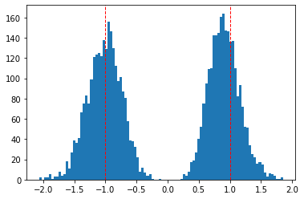

```python
result = plt.hist(np.sqrt(n)*u[:,0],bins=100)
plt.axvline(-1, color='red', linestyle='dashed', linewidth=1)
plt.axvline(1, color='red', linestyle='dashed', linewidth=1)
```

B. In the second simulation, we repeat the experiment 100 times and show the boxplot of three error measures.

```python
def simu_study(n,a,b,nrep,true_u,true_l):
    err = np.zeros((nrep,3))
    for i in range(nrep):
        A = simu_A(n,a,b)
        _,u = eigsh(A,2)
        err[i,0] = np.sqrt(n)*np.max(np.abs(np.abs(u[:,0])-np.abs(true_u)))
        temp = np.abs(np.matmul(A,true_u)/true_l)
        err[i,1] = np.sqrt(n)*np.max(np.abs(temp-np.abs(true_u)))
        err[i,2] = np.sqrt(n)*np.max(np.abs(np.abs(u[:,0]) - temp))
    return err
```

```python
true_u = np.repeat(np.array([1/np.sqrt(n),-1/np.sqrt(n)]),[int(n/2),int(n/2)])
true_l = (a-b)/2*np.log(n)
```

```python
nrep=100
out = simu_study(n,a,b,nrep,true_u,true_l)
```

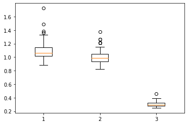

```python
bcplot = plt.boxplot(out)
```

## Figure 6(left)

The Vanilla spectral method is to first compute $u_2$, the eigenvector of $A$ corresponding to its second largest eigenvalue then set $\hat z = sign(u_2)$.

```python
def success_rate(predicted_label, true_label):
    n = len(true_label)
    t = (np.multiply(predicted_label,true_label))
    r = np.max(((t==1).sum()/n,(t==-1).sum()/n))
    return r
```

```python
n = 300
nrep = 100
step = 101
true_label = np.repeat(np.array([1,-1]),[int(n/2),int(n/2)])
a_list = np.linspace(start=30,stop=0,num=step)
b_list = np.linspace(start=0,stop=10,num=step)
succ_rate = np.zeros((len(a_list),len(b_list)))
for i in range(len(a_list)):
    for j in range(len(b_list)):
        succ_rate_temp = np.zeros((nrep))
        for r in range(nrep):
            A = simu_A(n,a_list[i],b_list[j])
            _,u = eigsh(A,2)
            succ_rate_temp[r] = success_rate(np.sign(u[:,0]),true_label)
        succ_rate[i,j] = np.mean(succ_rate_temp)
```

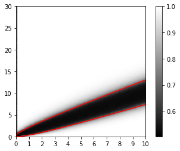

```python
fig, ax = plt.subplots(1,1)
img = ax.imshow(succ_rate,cmap='gray',extent = [0,100,0,100])
fig.colorbar(img,ax=ax)
x_label_list = [i for i in range(11)]
y_label_list = np.linspace(start=0,stop=30,num=7)
y_label_list = y_label_list.astype(int)
ax.set_xticks(np.linspace(start=0,stop=100,num=11))
ax.set_yticks(np.linspace(start=0,stop=100,num=7))
ax.set_xticklabels(x_label_list)
ax.set_yticklabels(y_label_list)

plt.plot(np.linspace(0,10,num=100)*10,(np.sqrt(np.linspace(0,10,num=100)*10)-np.sqrt(2))**2/3,color='red')
plt.plot(np.linspace(0,10,num=100)*10,(np.sqrt(np.linspace(0,10,num=100)*10)+np.sqrt(2))**2/3,color='red')
```